# Risk Factor Analysis

## Outcome Variable

**Outcome Variable:** y_rate_len

## Predictor Variables

**Intervention Variable:** predfeed6

**Adjustment Set:**

- arm
- sex
- month
- brthmon
- W_mage
- meducyrs
- feducyrs
- hhwealth_quart
- hfoodsec
- W_mhtcm
- vagbrth
- W_gagebrth
- W_birthwt
- W_birthlen
- W_nrooms
- W_nchldlt5
- W_parity
- impfloor
- impsan
- safeh20
- delta_W_mage
- delta_meducyrs
- delta_feducyrs
- delta_hhwealth_quart
- delta_hfoodsec
- delta_W_mhtcm
- delta_vagbrth
- delta_W_gagebrth
- delta_W_birthwt
- delta_W_birthlen
- delta_W_nrooms
- delta_W_nchldlt5
- delta_W_parity
- delta_impfloor
- delta_impsan
- delta_safeh20

## Stratifying Variables

The analysis was stratified on these variable(s):

- agecat
- studyid
- country

## Data Summary

| agecat | studyid | country | predfeed6 | n_cell | n |
| --- | --- | --- | --- | --- | --- |
| 0-3 months | ki0047075b-MAL-ED | BANGLADESH | 0 | 112 | 233 |
| 0-3 months | ki0047075b-MAL-ED | BANGLADESH | 1 | 121 | 233 |
| 0-3 months | ki0047075b-MAL-ED | BRAZIL | 0 | 148 | 175 |
| 0-3 months | ki0047075b-MAL-ED | BRAZIL | 1 | 27 | 175 |
| 0-3 months | ki0047075b-MAL-ED | INDIA | 0 | 178 | 193 |
| 0-3 months | ki0047075b-MAL-ED | INDIA | 1 | 15 | 193 |
| 0-3 months | ki0047075b-MAL-ED | NEPAL | 0 | 150 | 173 |
| 0-3 months | ki0047075b-MAL-ED | NEPAL | 1 | 23 | 173 |
| 0-3 months | ki0047075b-MAL-ED | PERU | 0 | 150 | 258 |
| 0-3 months | ki0047075b-MAL-ED | PERU | 1 | 108 | 258 |
| 0-3 months | ki0047075b-MAL-ED | SOUTH AFRICA | 0 | 206 | 209 |
| 0-3 months | ki0047075b-MAL-ED | SOUTH AFRICA | 1 | 3 | 209 |
| 0-3 months | ki0047075b-MAL-ED | TANZANIA, UNITED REPUBLIC OF | 0 | 223 | 224 |
| 0-3 months | ki0047075b-MAL-ED | TANZANIA, UNITED REPUBLIC OF | 1 | 1 | 224 |
| 0-3 months | ki1000109-EE | PAKISTAN | 0 | 260 | 594 |
| 0-3 months | ki1000109-EE | PAKISTAN | 1 | 334 | 594 |
| 0-3 months | kiGH5241-JiVitA-3 | BANGLADESH | 0 | 8676 | 40078 |
| 0-3 months | kiGH5241-JiVitA-3 | BANGLADESH | 1 | 31402 | 40078 |
| 0-3 months | kiGH5241-JiVitA-4 | BANGLADESH | 0 | 586 | 3610 |
| 0-3 months | kiGH5241-JiVitA-4 | BANGLADESH | 1 | 3024 | 3610 |
| 3-6 months | ki0047075b-MAL-ED | BANGLADESH | 0 | 108 | 225 |
| 3-6 months | ki0047075b-MAL-ED | BANGLADESH | 1 | 117 | 225 |
| 3-6 months | ki0047075b-MAL-ED | BRAZIL | 0 | 173 | 208 |
| 3-6 months | ki0047075b-MAL-ED | BRAZIL | 1 | 35 | 208 |
| 3-6 months | ki0047075b-MAL-ED | INDIA | 0 | 207 | 225 |
| 3-6 months | ki0047075b-MAL-ED | INDIA | 1 | 18 | 225 |
| 3-6 months | ki0047075b-MAL-ED | NEPAL | 0 | 205 | 232 |
| 3-6 months | ki0047075b-MAL-ED | NEPAL | 1 | 27 | 232 |
| 3-6 months | ki0047075b-MAL-ED | PERU | 0 | 153 | 264 |
| 3-6 months | ki0047075b-MAL-ED | PERU | 1 | 111 | 264 |

[output cut: 60 more lines]

The following strata were considered:

- agecat: 0-3 months, studyid: ki0047075b-MAL-ED, country: BANGLADESH
- agecat: 0-3 months, studyid: ki0047075b-MAL-ED, country: BRAZIL
- agecat: 0-3 months, studyid: ki0047075b-MAL-ED, country: INDIA
- agecat: 0-3 months, studyid: ki0047075b-MAL-ED, country: NEPAL
- agecat: 0-3 months, studyid: ki0047075b-MAL-ED, country: PERU
- agecat: 0-3 months, studyid: ki0047075b-MAL-ED, country: SOUTH AFRICA
- agecat: 0-3 months, studyid: ki0047075b-MAL-ED, country: TANZANIA, UNITED REPUBLIC OF
- agecat: 0-3 months, studyid: ki1000109-EE, country: PAKISTAN
- agecat: 0-3 months, studyid: kiGH5241-JiVitA-3, country: BANGLADESH
- agecat: 0-3 months, studyid: kiGH5241-JiVitA-4, country: BANGLADESH
- agecat: 12-24 months, studyid: ki0047075b-MAL-ED, country: BANGLADESH
- agecat: 12-24 months, studyid: ki0047075b-MAL-ED, country: BRAZIL
- agecat: 12-24 months, studyid: ki0047075b-MAL-ED, country: INDIA
- agecat: 12-24 months, studyid: ki0047075b-MAL-ED, country: NEPAL
- agecat: 12-24 months, studyid: ki0047075b-MAL-ED, country: PERU
- agecat: 12-24 months, studyid: ki0047075b-MAL-ED, country: SOUTH AFRICA
- agecat: 12-24 months, studyid: ki0047075b-MAL-ED, country: TANZANIA, UNITED REPUBLIC OF
- agecat: 12-24 months, studyid: ki1113344-GMS-Nepal, country: NEPAL
- agecat: 12-24 months, studyid: ki1148112-LCNI-5, country: MALAWI
- agecat: 12-24 months, studyid: kiGH5241-JiVitA-3, country: BANGLADESH
- agecat: 12-24 months, studyid: kiGH5241-JiVitA-4, country: BANGLADESH
- agecat: 3-6 months, studyid: ki0047075b-MAL-ED, country: BANGLADESH
- agecat: 3-6 months, studyid: ki0047075b-MAL-ED, country: BRAZIL
- agecat: 3-6 months, studyid: ki0047075b-MAL-ED, country: INDIA
- agecat: 3-6 months, studyid: ki0047075b-MAL-ED, country: NEPAL
- agecat: 3-6 months, studyid: ki0047075b-MAL-ED, country: PERU
- agecat: 3-6 months, studyid: ki0047075b-MAL-ED, country: SOUTH AFRICA
- agecat: 3-6 months, studyid: ki0047075b-MAL-ED, country: TANZANIA, UNITED REPUBLIC OF
- agecat: 3-6 months, studyid: ki1000109-EE, country: PAKISTAN
- agecat: 3-6 months, studyid: ki1113344-GMS-Nepal, country: NEPAL
- agecat: 3-6 months, studyid: kiGH5241-JiVitA-3, country: BANGLADESH
- agecat: 3-6 months, studyid: kiGH5241-JiVitA-4, country: BANGLADESH
- agecat: 6-12 months, studyid: ki0047075b-MAL-ED, country: BANGLADESH
- agecat: 6-12 months, studyid: ki0047075b-MAL-ED, country: BRAZIL
- agecat: 6-12 months, studyid: ki0047075b-MAL-ED, country: INDIA
- agecat: 6-12 months, studyid: ki0047075b-MAL-ED, country: NEPAL
- agecat: 6-12 months, studyid: ki0047075b-MAL-ED, country: PERU
- agecat: 6-12 months, studyid: ki0047075b-MAL-ED, country: SOUTH AFRICA
- agecat: 6-12 months, studyid: ki0047075b-MAL-ED, country: TANZANIA, UNITED REPUBLIC OF
- agecat: 6-12 months, studyid: ki1000109-EE, country: PAKISTAN
- agecat: 6-12 months, studyid: ki1000304b-SAS-FoodSuppl, country: INDIA
- agecat: 6-12 months, studyid: ki1113344-GMS-Nepal, country: NEPAL
- agecat: 6-12 months, studyid: ki1148112-LCNI-5, country: MALAWI
- agecat: 6-12 months, studyid: kiGH5241-JiVitA-3, country: BANGLADESH
- agecat: 6-12 months, studyid: kiGH5241-JiVitA-4, country: BANGLADESH

### Dropped Strata

Some strata were dropped due to rare outcomes:

- agecat: 0-3 months, studyid: ki0047075b-MAL-ED, country: SOUTH AFRICA
- agecat: 0-3 months, studyid: ki0047075b-MAL-ED, country: TANZANIA, UNITED REPUBLIC OF
- agecat: 3-6 months, studyid: ki0047075b-MAL-ED, country: SOUTH AFRICA
- agecat: 3-6 months, studyid: ki0047075b-MAL-ED, country: TANZANIA, UNITED REPUBLIC OF
- agecat: 6-12 months, studyid: ki0047075b-MAL-ED, country: SOUTH AFRICA
- agecat: 6-12 months, studyid: ki0047075b-MAL-ED, country: TANZANIA, UNITED REPUBLIC OF
- agecat: 6-12 months, studyid: ki1000109-EE, country: PAKISTAN
- agecat: 6-12 months, studyid: ki1000304b-SAS-FoodSuppl, country: INDIA
- agecat: 12-24 months, studyid: ki0047075b-MAL-ED, country: SOUTH AFRICA
- agecat: 12-24 months, studyid: ki0047075b-MAL-ED, country: TANZANIA, UNITED REPUBLIC OF

## Methods Detail

We’re interested in the causal parameters $E[Y_a]$ for all values of $a \in \mathcal{A}$. These parameters represent the mean outcome if, possibly contrary to fact, we intervened to set all units to have $A=a$. Under the randomization and positivity assumptions, these are identified by the statistical parameters $\psi_a=E_W[E_{Y|A,W}(Y|A=a,W)]$. In addition, we’re interested in the mean of $Y$, $E[Y]$ under no intervention (the observed mean). We will estimate these parameters by using SuperLearner to fit the relevant likelihood factors – $E_{Y|A,W}(Y|A=a,W)$ and $p(A=a|W)$, and then updating our likelihood fit using a joint TMLE.

For unadjusted analyses ($W=\{\}$), initial likelihoods were estimated using Lrnr_glm to estimate the simple $E(Y|A)$ and Lrnr_mean to estimate $p(A)$. For adjusted analyses, a small library containing Lrnr_glmnet, Lrnr_xgboost, and Lrnr_mean was used.

# Results Detail

## Results Plots

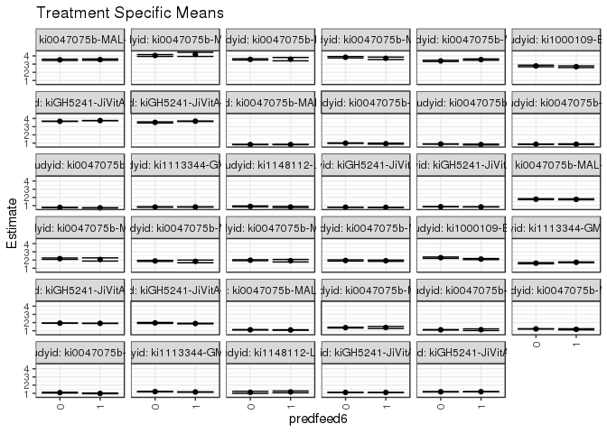

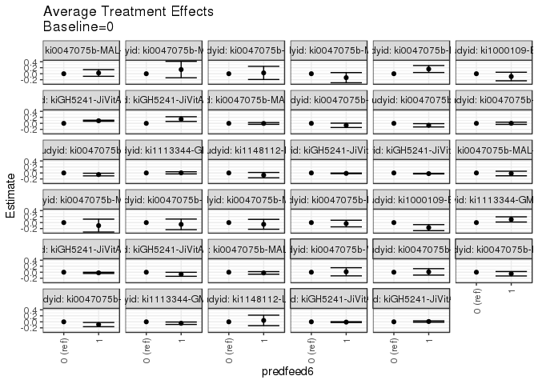

## Results Table

### Parameter: TSM

| agecat | studyid | country | intervention_level | baseline_level | estimate | ci_lower | ci_upper |
| --- | --- | --- | --- | --- | --- | --- | --- |
| 0-3 months | ki0047075b-MAL-ED | BANGLADESH | 0 | NA | 3.5173801 | 3.4352712 | 3.5994890 |
| 0-3 months | ki0047075b-MAL-ED | BANGLADESH | 1 | NA | 3.5429967 | 3.4609115 | 3.6250819 |
| 0-3 months | ki0047075b-MAL-ED | BRAZIL | 0 | NA | 4.0474880 | 3.9359327 | 4.1590434 |
| 0-3 months | ki0047075b-MAL-ED | BRAZIL | 1 | NA | 4.1862059 | 3.9359412 | 4.4364707 |
| 0-3 months | ki0047075b-MAL-ED | INDIA | 0 | NA | 3.5742994 | 3.4934292 | 3.6551696 |
| 0-3 months | ki0047075b-MAL-ED | INDIA | 1 | NA | 3.6018150 | 3.3967739 | 3.8068560 |
| 0-3 months | ki0047075b-MAL-ED | NEPAL | 0 | NA | 3.8344867 | 3.7497321 | 3.9192412 |
| 0-3 months | ki0047075b-MAL-ED | NEPAL | 1 | NA | 3.7034143 | 3.5556502 | 3.8511783 |
| 0-3 months | ki0047075b-MAL-ED | PERU | 0 | NA | 3.3891377 | 3.3108306 | 3.4674448 |
| 0-3 months | ki0047075b-MAL-ED | PERU | 1 | NA | 3.5459677 | 3.4626806 | 3.6292548 |
| 0-3 months | ki1000109-EE | PAKISTAN | 0 | NA | 2.7751612 | 2.6771654 | 2.8731571 |
| 0-3 months | ki1000109-EE | PAKISTAN | 1 | NA | 2.6820101 | 2.5789142 | 2.7851060 |
| 0-3 months | kiGH5241-JiVitA-3 | BANGLADESH | 0 | NA | 3.6558643 | 3.6390988 | 3.6726299 |
| 0-3 months | kiGH5241-JiVitA-3 | BANGLADESH | 1 | NA | 3.7420532 | 3.7310860 | 3.7530205 |
| 0-3 months | kiGH5241-JiVitA-4 | BANGLADESH | 0 | NA | 3.5219622 | 3.4505670 | 3.5933574 |
| 0-3 months | kiGH5241-JiVitA-4 | BANGLADESH | 1 | NA | 3.6635308 | 3.6307894 | 3.6962722 |
| 3-6 months | ki0047075b-MAL-ED | BANGLADESH | 0 | NA | 1.7870640 | 1.7297711 | 1.8443570 |
| 3-6 months | ki0047075b-MAL-ED | BANGLADESH | 1 | NA | 1.7691220 | 1.7131311 | 1.8251129 |
| 3-6 months | ki0047075b-MAL-ED | BRAZIL | 0 | NA | 2.1646904 | 2.0784049 | 2.2509759 |
| 3-6 months | ki0047075b-MAL-ED | BRAZIL | 1 | NA | 2.0644055 | 1.8680040 | 2.2608070 |
| 3-6 months | ki0047075b-MAL-ED | INDIA | 0 | NA | 1.8886636 | 1.8227391 | 1.9545881 |
| 3-6 months | ki0047075b-MAL-ED | INDIA | 1 | NA | 1.8292377 | 1.6653601 | 1.9931152 |
| 3-6 months | ki0047075b-MAL-ED | NEPAL | 0 | NA | 1.9740592 | 1.9139709 | 2.0341475 |
| 3-6 months | ki0047075b-MAL-ED | NEPAL | 1 | NA | 1.9165320 | 1.7625721 | 2.0704919 |
| 3-6 months | ki0047075b-MAL-ED | PERU | 0 | NA | 1.9439198 | 1.8668595 | 2.0209801 |
| 3-6 months | ki0047075b-MAL-ED | PERU | 1 | NA | 1.9120301 | 1.8299997 | 1.9940606 |
| 3-6 months | ki1000109-EE | PAKISTAN | 0 | NA | 2.2819006 | 2.2017372 | 2.3620640 |
| 3-6 months | ki1000109-EE | PAKISTAN | 1 | NA | 2.1141116 | 2.0496273 | 2.1785960 |
| 3-6 months | ki1113344-GMS-Nepal | NEPAL | 0 | NA | 1.6147236 | 1.5403624 | 1.6890848 |
| 3-6 months | ki1113344-GMS-Nepal | NEPAL | 1 | NA | 1.7193994 | 1.6743029 | 1.7644959 |
| 3-6 months | kiGH5241-JiVitA-3 | BANGLADESH | 0 | NA | 1.9290431 | 1.9108763 | 1.9472099 |
| 3-6 months | kiGH5241-JiVitA-3 | BANGLADESH | 1 | NA | 1.9080588 | 1.8969035 | 1.9192141 |
| 3-6 months | kiGH5241-JiVitA-4 | BANGLADESH | 0 | NA | 1.9551951 | 1.8939237 | 2.0164664 |
| 3-6 months | kiGH5241-JiVitA-4 | BANGLADESH | 1 | NA | 1.8856825 | 1.8533917 | 1.9179733 |
| 6-12 months | ki0047075b-MAL-ED | BANGLADESH | 0 | NA | 1.1200690 | 1.0875884 | 1.1525496 |
| 6-12 months | ki0047075b-MAL-ED | BANGLADESH | 1 | NA | 1.0966746 | 1.0667530 | 1.1265962 |
| 6-12 months | ki0047075b-MAL-ED | BRAZIL | 0 | NA | 1.3839743 | 1.3348400 | 1.4331087 |
| 6-12 months | ki0047075b-MAL-ED | BRAZIL | 1 | NA | 1.3979175 | 1.2708078 | 1.5250272 |
| 6-12 months | ki0047075b-MAL-ED | INDIA | 0 | NA | 1.1206414 | 1.0906653 | 1.1506175 |
| 6-12 months | ki0047075b-MAL-ED | INDIA | 1 | NA | 1.1310767 | 1.0284433 | 1.2337100 |
| 6-12 months | ki0047075b-MAL-ED | NEPAL | 0 | NA | 1.2295157 | 1.2028728 | 1.2561586 |
| 6-12 months | ki0047075b-MAL-ED | NEPAL | 1 | NA | 1.1779917 | 1.1068264 | 1.2491569 |
| 6-12 months | ki0047075b-MAL-ED | PERU | 0 | NA | 1.0859449 | 1.0399136 | 1.1319761 |
| 6-12 months | ki0047075b-MAL-ED | PERU | 1 | NA | 0.9937315 | 0.9492474 | 1.0382157 |
| 6-12 months | ki1113344-GMS-Nepal | NEPAL | 0 | NA | 1.2142421 | 1.1798952 | 1.2485890 |
| 6-12 months | ki1113344-GMS-Nepal | NEPAL | 1 | NA | 1.1669573 | 1.1449794 | 1.1889351 |
| 6-12 months | ki1148112-LCNI-5 | MALAWI | 0 | NA | 1.1280693 | 1.0041832 | 1.2519554 |
| 6-12 months | ki1148112-LCNI-5 | MALAWI | 1 | NA | 1.1747204 | 1.0670414 | 1.2823994 |
| 6-12 months | kiGH5241-JiVitA-3 | BANGLADESH | 0 | NA | 1.1141109 | 1.1019970 | 1.1262249 |
| 6-12 months | kiGH5241-JiVitA-3 | BANGLADESH | 1 | NA | 1.1045591 | 1.0973556 | 1.1117625 |
| 6-12 months | kiGH5241-JiVitA-4 | BANGLADESH | 0 | NA | 1.1904096 | 1.1701931 | 1.2106260 |
| 6-12 months | kiGH5241-JiVitA-4 | BANGLADESH | 1 | NA | 1.2006589 | 1.1883718 | 1.2129459 |
| 12-24 months | ki0047075b-MAL-ED | BANGLADESH | 0 | NA | 0.8214244 | 0.7993641 | 0.8434848 |
| 12-24 months | ki0047075b-MAL-ED | BANGLADESH | 1 | NA | 0.8187689 | 0.7982787 | 0.8392591 |
| 12-24 months | ki0047075b-MAL-ED | BRAZIL | 0 | NA | 0.9933254 | 0.9603310 | 1.0263197 |
| 12-24 months | ki0047075b-MAL-ED | BRAZIL | 1 | NA | 0.9277146 | 0.8625531 | 0.9928760 |
| 12-24 months | ki0047075b-MAL-ED | INDIA | 0 | NA | 0.8852575 | 0.8669853 | 0.9035297 |
| 12-24 months | ki0047075b-MAL-ED | INDIA | 1 | NA | 0.8200841 | 0.7677023 | 0.8724659 |
| 12-24 months | ki0047075b-MAL-ED | NEPAL | 0 | NA | 0.8607716 | 0.8439821 | 0.8775611 |
| 12-24 months | ki0047075b-MAL-ED | NEPAL | 1 | NA | 0.8634553 | 0.8299674 | 0.8969432 |
| 12-24 months | ki0047075b-MAL-ED | PERU | 0 | NA | 0.7812585 | 0.7530667 | 0.8094503 |
| 12-24 months | ki0047075b-MAL-ED | PERU | 1 | NA | 0.7279257 | 0.7003892 | 0.7554621 |
| 12-24 months | ki1113344-GMS-Nepal | NEPAL | 0 | NA | 0.8329469 | 0.8010451 | 0.8648488 |
| 12-24 months | ki1113344-GMS-Nepal | NEPAL | 1 | NA | 0.8370320 | 0.8194126 | 0.8546514 |
| 12-24 months | ki1148112-LCNI-5 | MALAWI | 0 | NA | 0.9052456 | 0.8493606 | 0.9611306 |
| 12-24 months | ki1148112-LCNI-5 | MALAWI | 1 | NA | 0.8330056 | 0.7639315 | 0.9020797 |
| 12-24 months | kiGH5241-JiVitA-3 | BANGLADESH | 0 | NA | 0.8061739 | 0.7966926 | 0.8156553 |
| 12-24 months | kiGH5241-JiVitA-3 | BANGLADESH | 1 | NA | 0.7926546 | 0.7870647 | 0.7982445 |
| 12-24 months | kiGH5241-JiVitA-4 | BANGLADESH | 0 | NA | 0.8678439 | 0.8586452 | 0.8770426 |
| 12-24 months | kiGH5241-JiVitA-4 | BANGLADESH | 1 | NA | 0.8456975 | 0.8394362 | 0.8519588 |

### Parameter: E(Y)

| agecat | studyid | country | intervention_level | baseline_level | estimate | ci_lower | ci_upper |
| --- | --- | --- | --- | --- | --- | --- | --- |
| 0-3 months | ki0047075b-MAL-ED | BANGLADESH | NA | NA | 3.5553847 | 3.4920868 | 3.6186827 |
| 0-3 months | ki0047075b-MAL-ED | BRAZIL | NA | NA | 4.0688851 | 3.9665094 | 4.1712608 |
| 0-3 months | ki0047075b-MAL-ED | INDIA | NA | NA | 3.5729366 | 3.4957568 | 3.6501164 |
| 0-3 months | ki0047075b-MAL-ED | NEPAL | NA | NA | 3.8170740 | 3.7403102 | 3.8938378 |
| 0-3 months | ki0047075b-MAL-ED | PERU | NA | NA | 3.3318351 | 3.2689715 | 3.3946986 |
| 0-3 months | ki1000109-EE | PAKISTAN | NA | NA | 2.6575645 | 2.5739973 | 2.7411317 |
| 0-3 months | kiGH5241-JiVitA-3 | BANGLADESH | NA | NA | 3.7185042 | 3.7081620 | 3.7288464 |
| 0-3 months | kiGH5241-JiVitA-4 | BANGLADESH | NA | NA | 3.6386843 | 3.6074983 | 3.6698703 |
| 3-6 months | ki0047075b-MAL-ED | BANGLADESH | NA | NA | 1.9343889 | 1.8844588 | 1.9843190 |
| 3-6 months | ki0047075b-MAL-ED | BRAZIL | NA | NA | 2.1478156 | 2.0686357 | 2.2269955 |
| 3-6 months | ki0047075b-MAL-ED | INDIA | NA | NA | 1.8839095 | 1.8218223 | 1.9459968 |
| 3-6 months | ki0047075b-MAL-ED | NEPAL | NA | NA | 1.9673620 | 1.9110737 | 2.0236503 |
| 3-6 months | ki0047075b-MAL-ED | PERU | NA | NA | 2.0207669 | 1.9549762 | 2.0865576 |
| 3-6 months | ki1000109-EE | PAKISTAN | NA | NA | 2.0241201 | 1.9636505 | 2.0845898 |
| 3-6 months | ki1113344-GMS-Nepal | NEPAL | NA | NA | 1.7048001 | 1.6654509 | 1.7441494 |
| 3-6 months | kiGH5241-JiVitA-3 | BANGLADESH | NA | NA | 1.9200510 | 1.9095836 | 1.9305183 |
| 3-6 months | kiGH5241-JiVitA-4 | BANGLADESH | NA | NA | 1.8963650 | 1.8662030 | 1.9265270 |
| 6-12 months | ki0047075b-MAL-ED | BANGLADESH | NA | NA | 1.1131603 | 1.0877615 | 1.1385590 |
| 6-12 months | ki0047075b-MAL-ED | BRAZIL | NA | NA | 1.3863464 | 1.3400121 | 1.4326807 |
| 6-12 months | ki0047075b-MAL-ED | INDIA | NA | NA | 1.1214539 | 1.0926522 | 1.1502556 |
| 6-12 months | ki0047075b-MAL-ED | NEPAL | NA | NA | 1.2234287 | 1.1975908 | 1.2492667 |
| 6-12 months | ki0047075b-MAL-ED | PERU | NA | NA | 1.2081188 | 1.1752622 | 1.2409753 |
| 6-12 months | ki1113344-GMS-Nepal | NEPAL | NA | NA | 1.1659725 | 1.1463312 | 1.1856138 |
| 6-12 months | ki1148112-LCNI-5 | MALAWI | NA | NA | 1.2437855 | 1.1489803 | 1.3385906 |
| 6-12 months | kiGH5241-JiVitA-3 | BANGLADESH | NA | NA | 1.1067177 | 1.0999609 | 1.1134745 |
| 6-12 months | kiGH5241-JiVitA-4 | BANGLADESH | NA | NA | 1.2020599 | 1.1906612 | 1.2134585 |
| 12-24 months | ki0047075b-MAL-ED | BANGLADESH | NA | NA | 0.8457372 | 0.8296411 | 0.8618334 |
| 12-24 months | ki0047075b-MAL-ED | BRAZIL | NA | NA | 0.9816245 | 0.9508764 | 1.0123725 |
| 12-24 months | ki0047075b-MAL-ED | INDIA | NA | NA | 0.8802656 | 0.8627612 | 0.8977700 |
| 12-24 months | ki0047075b-MAL-ED | NEPAL | NA | NA | 0.8610937 | 0.8457157 | 0.8764716 |
| 12-24 months | ki0047075b-MAL-ED | PERU | NA | NA | 0.8498071 | 0.8294861 | 0.8701282 |
| 12-24 months | ki1113344-GMS-Nepal | NEPAL | NA | NA | 0.8363408 | 0.8207398 | 0.8519417 |
| 12-24 months | ki1148112-LCNI-5 | MALAWI | NA | NA | 0.8835736 | 0.8376943 | 0.9294529 |
| 12-24 months | kiGH5241-JiVitA-3 | BANGLADESH | NA | NA | 0.7961667 | 0.7908693 | 0.8014641 |
| 12-24 months | kiGH5241-JiVitA-4 | BANGLADESH | NA | NA | 0.8490267 | 0.8432029 | 0.8548505 |

### Parameter: ATE

| agecat | studyid | country | intervention_level | baseline_level | estimate | ci_lower | ci_upper |
| --- | --- | --- | --- | --- | --- | --- | --- |
| 0-3 months | ki0047075b-MAL-ED | BANGLADESH | 0 | 0 | 0.0000000 | 0.0000000 | 0.0000000 |
| 0-3 months | ki0047075b-MAL-ED | BANGLADESH | 1 | 0 | 0.0256166 | -0.0860011 | 0.1372343 |
| 0-3 months | ki0047075b-MAL-ED | BRAZIL | 0 | 0 | 0.0000000 | 0.0000000 | 0.0000000 |
| 0-3 months | ki0047075b-MAL-ED | BRAZIL | 1 | 0 | 0.1387179 | -0.1347862 | 0.4122220 |
| 0-3 months | ki0047075b-MAL-ED | INDIA | 0 | 0 | 0.0000000 | 0.0000000 | 0.0000000 |
| 0-3 months | ki0047075b-MAL-ED | INDIA | 1 | 0 | 0.0275156 | -0.1916179 | 0.2466491 |
| 0-3 months | ki0047075b-MAL-ED | NEPAL | 0 | 0 | 0.0000000 | 0.0000000 | 0.0000000 |
| 0-3 months | ki0047075b-MAL-ED | NEPAL | 1 | 0 | -0.1310724 | -0.3000291 | 0.0378843 |
| 0-3 months | ki0047075b-MAL-ED | PERU | 0 | 0 | 0.0000000 | 0.0000000 | 0.0000000 |
| 0-3 months | ki0047075b-MAL-ED | PERU | 1 | 0 | 0.1568300 | 0.0404905 | 0.2731695 |
| 0-3 months | ki1000109-EE | PAKISTAN | 0 | 0 | 0.0000000 | 0.0000000 | 0.0000000 |
| 0-3 months | ki1000109-EE | PAKISTAN | 1 | 0 | -0.0931512 | -0.2356454 | 0.0493431 |
| 0-3 months | kiGH5241-JiVitA-3 | BANGLADESH | 0 | 0 | 0.0000000 | 0.0000000 | 0.0000000 |
| 0-3 months | kiGH5241-JiVitA-3 | BANGLADESH | 1 | 0 | 0.0861889 | 0.0680734 | 0.1043044 |
| 0-3 months | kiGH5241-JiVitA-4 | BANGLADESH | 0 | 0 | 0.0000000 | 0.0000000 | 0.0000000 |
| 0-3 months | kiGH5241-JiVitA-4 | BANGLADESH | 1 | 0 | 0.1415686 | 0.0632005 | 0.2199367 |
| 3-6 months | ki0047075b-MAL-ED | BANGLADESH | 0 | 0 | 0.0000000 | 0.0000000 | 0.0000000 |
| 3-6 months | ki0047075b-MAL-ED | BANGLADESH | 1 | 0 | -0.0179420 | -0.0941781 | 0.0582940 |
| 3-6 months | ki0047075b-MAL-ED | BRAZIL | 0 | 0 | 0.0000000 | 0.0000000 | 0.0000000 |
| 3-6 months | ki0047075b-MAL-ED | BRAZIL | 1 | 0 | -0.1002849 | -0.3147932 | 0.1142233 |
| 3-6 months | ki0047075b-MAL-ED | INDIA | 0 | 0 | 0.0000000 | 0.0000000 | 0.0000000 |
| 3-6 months | ki0047075b-MAL-ED | INDIA | 1 | 0 | -0.0594259 | -0.2360665 | 0.1172146 |
| 3-6 months | ki0047075b-MAL-ED | NEPAL | 0 | 0 | 0.0000000 | 0.0000000 | 0.0000000 |
| 3-6 months | ki0047075b-MAL-ED | NEPAL | 1 | 0 | -0.0575272 | -0.2221828 | 0.1071284 |
| 3-6 months | ki0047075b-MAL-ED | PERU | 0 | 0 | 0.0000000 | 0.0000000 | 0.0000000 |
| 3-6 months | ki0047075b-MAL-ED | PERU | 1 | 0 | -0.0318897 | -0.1420012 | 0.0782219 |
| 3-6 months | ki1000109-EE | PAKISTAN | 0 | 0 | 0.0000000 | 0.0000000 | 0.0000000 |
| 3-6 months | ki1000109-EE | PAKISTAN | 1 | 0 | -0.1677889 | -0.2677565 | -0.0678214 |
| 3-6 months | ki1113344-GMS-Nepal | NEPAL | 0 | 0 | 0.0000000 | 0.0000000 | 0.0000000 |
| 3-6 months | ki1113344-GMS-Nepal | NEPAL | 1 | 0 | 0.1046758 | 0.0182730 | 0.1910786 |
| 3-6 months | kiGH5241-JiVitA-3 | BANGLADESH | 0 | 0 | 0.0000000 | 0.0000000 | 0.0000000 |
| 3-6 months | kiGH5241-JiVitA-3 | BANGLADESH | 1 | 0 | -0.0209843 | -0.0411065 | -0.0008622 |
| 3-6 months | kiGH5241-JiVitA-4 | BANGLADESH | 0 | 0 | 0.0000000 | 0.0000000 | 0.0000000 |
| 3-6 months | kiGH5241-JiVitA-4 | BANGLADESH | 1 | 0 | -0.0695126 | -0.1359531 | -0.0030720 |
| 6-12 months | ki0047075b-MAL-ED | BANGLADESH | 0 | 0 | 0.0000000 | 0.0000000 | 0.0000000 |
| 6-12 months | ki0047075b-MAL-ED | BANGLADESH | 1 | 0 | -0.0233944 | -0.0658411 | 0.0190524 |
| 6-12 months | ki0047075b-MAL-ED | BRAZIL | 0 | 0 | 0.0000000 | 0.0000000 | 0.0000000 |
| 6-12 months | ki0047075b-MAL-ED | BRAZIL | 1 | 0 | 0.0139431 | -0.1219125 | 0.1497988 |
| 6-12 months | ki0047075b-MAL-ED | INDIA | 0 | 0 | 0.0000000 | 0.0000000 | 0.0000000 |
| 6-12 months | ki0047075b-MAL-ED | INDIA | 1 | 0 | 0.0104353 | -0.0964303 | 0.1173009 |
| 6-12 months | ki0047075b-MAL-ED | NEPAL | 0 | 0 | 0.0000000 | 0.0000000 | 0.0000000 |
| 6-12 months | ki0047075b-MAL-ED | NEPAL | 1 | 0 | -0.0515240 | -0.1257892 | 0.0227411 |
| 6-12 months | ki0047075b-MAL-ED | PERU | 0 | 0 | 0.0000000 | 0.0000000 | 0.0000000 |
| 6-12 months | ki0047075b-MAL-ED | PERU | 1 | 0 | -0.0922133 | -0.1623563 | -0.0220704 |
| 6-12 months | ki1113344-GMS-Nepal | NEPAL | 0 | 0 | 0.0000000 | 0.0000000 | 0.0000000 |
| 6-12 months | ki1113344-GMS-Nepal | NEPAL | 1 | 0 | -0.0472848 | -0.0879583 | -0.0066113 |
| 6-12 months | ki1148112-LCNI-5 | MALAWI | 0 | 0 | 0.0000000 | 0.0000000 | 0.0000000 |
| 6-12 months | ki1148112-LCNI-5 | MALAWI | 1 | 0 | 0.0466511 | -0.1276532 | 0.2209554 |
| 6-12 months | kiGH5241-JiVitA-3 | BANGLADESH | 0 | 0 | 0.0000000 | 0.0000000 | 0.0000000 |
| 6-12 months | kiGH5241-JiVitA-3 | BANGLADESH | 1 | 0 | -0.0095518 | -0.0229022 | 0.0037985 |
| 6-12 months | kiGH5241-JiVitA-4 | BANGLADESH | 0 | 0 | 0.0000000 | 0.0000000 | 0.0000000 |
| 6-12 months | kiGH5241-JiVitA-4 | BANGLADESH | 1 | 0 | 0.0102493 | -0.0123372 | 0.0328358 |
| 12-24 months | ki0047075b-MAL-ED | BANGLADESH | 0 | 0 | 0.0000000 | 0.0000000 | 0.0000000 |
| 12-24 months | ki0047075b-MAL-ED | BANGLADESH | 1 | 0 | -0.0026555 | -0.0324085 | 0.0270975 |
| 12-24 months | ki0047075b-MAL-ED | BRAZIL | 0 | 0 | 0.0000000 | 0.0000000 | 0.0000000 |
| 12-24 months | ki0047075b-MAL-ED | BRAZIL | 1 | 0 | -0.0656108 | -0.1377399 | 0.0065183 |
| 12-24 months | ki0047075b-MAL-ED | INDIA | 0 | 0 | 0.0000000 | 0.0000000 | 0.0000000 |
| 12-24 months | ki0047075b-MAL-ED | INDIA | 1 | 0 | -0.0651734 | -0.1205729 | -0.0097739 |
| 12-24 months | ki0047075b-MAL-ED | NEPAL | 0 | 0 | 0.0000000 | 0.0000000 | 0.0000000 |
| 12-24 months | ki0047075b-MAL-ED | NEPAL | 1 | 0 | 0.0026837 | -0.0345214 | 0.0398887 |
| 12-24 months | ki0047075b-MAL-ED | PERU | 0 | 0 | 0.0000000 | 0.0000000 | 0.0000000 |
| 12-24 months | ki0047075b-MAL-ED | PERU | 1 | 0 | -0.0533328 | -0.0969282 | -0.0097375 |
| 12-24 months | ki1113344-GMS-Nepal | NEPAL | 0 | 0 | 0.0000000 | 0.0000000 | 0.0000000 |
| 12-24 months | ki1113344-GMS-Nepal | NEPAL | 1 | 0 | 0.0040851 | -0.0320523 | 0.0402224 |
| 12-24 months | ki1148112-LCNI-5 | MALAWI | 0 | 0 | 0.0000000 | 0.0000000 | 0.0000000 |
| 12-24 months | ki1148112-LCNI-5 | MALAWI | 1 | 0 | -0.0722400 | -0.1610902 | 0.0166103 |
| 12-24 months | kiGH5241-JiVitA-3 | BANGLADESH | 0 | 0 | 0.0000000 | 0.0000000 | 0.0000000 |
| 12-24 months | kiGH5241-JiVitA-3 | BANGLADESH | 1 | 0 | -0.0135193 | -0.0239253 | -0.0031133 |
| 12-24 months | kiGH5241-JiVitA-4 | BANGLADESH | 0 | 0 | 0.0000000 | 0.0000000 | 0.0000000 |
| 12-24 months | kiGH5241-JiVitA-4 | BANGLADESH | 1 | 0 | -0.0221464 | -0.0326417 | -0.0116512 |